# Kernel-based methods

Published

5 Apr 2023

## Kernel-based methods

- depend only on some *distance function* induced between pairs of points
  - potentially a high (even infinite-dimensional!) space
  - mapping original values to high dim (e.g. high-order interactions)
- kernel function $k$
  - classification: $\hat y_i(\mathbf x') = \textrm{sign} \sum w_i y_i k(\mathbf x_i, \mathbf x')$
  - regression: (the same but without the !)
- for further efficiency can also use **low-rank approximations** of $k()$

## Kernel smoothers

- kernel density estimation
- Nadaraya-Watson kernel regession

## Separating hyperplanes

- ESL section 4.5
- Regress $\mathbf y\in \{-1, 1\}$ on $\mathbf x$: solve for $\mathbf X\boldsymbol \beta= 0$  
  (write as $\beta_0 + \beta^\top \mathbf x= 0$, i.e. separate intercept)
- (equivalent to linear discriminant analysis)
- Rosenblatt’s algorithm
  - $(\mathbf X\boldsymbol \beta)/||\boldsymbol \beta||$ is the signed distance to the separating plane
  - minimize $-\sum_{i \in {\cal M}} y_i (\mathbf X\beta)$ (sum of misclassified distances)
    - gradient wrt $\beta$ = $-\sum (y_i x_i)$
  - stochastic gradient descent (pointwise): adjust $\boldsymbol \beta$ by $\rho \mathbf y_i X_i$ at each step
- elegant but not practical (non-unique, slow, non-convergent if not separable)
- $\to$ penalized version in a larger basis space
- $\textrm{argmin}(\boldsymbol \beta)$ of $\frac{1}{2} ||\boldsymbol \beta||^2$ subject to $y_i (\mathbf X\beta) \ge 1$
- “standard” convex optimization problem

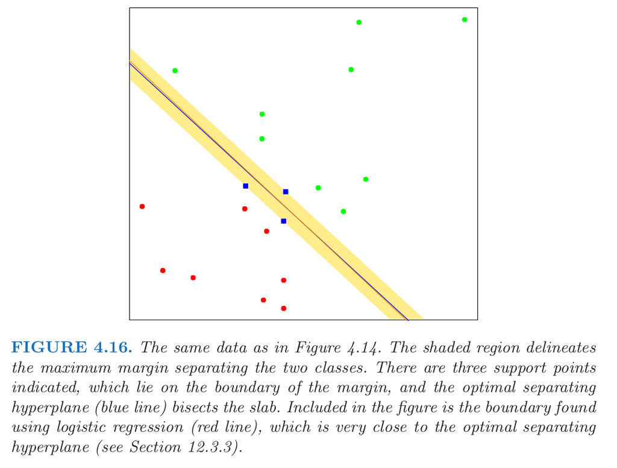

## support vector machines for the non-separable case

- ESL chapter 12
- $y_i (X_i \boldsymbol \beta\ge M(1-\xi_i)$
- linear loss function on misclassification distances + L2 penalty
- or $\textrm{min} \frac{1}{2} ||\beta||^2 + C \sum \xi_i$
- $C$ is the hyperparameter
- quadratic programming problem

## SVMs and kernels (ESL 12.3)

- alternative formulation

$$\begin{split}
f(x_i) & = X_i^\top \beta + \beta_0 \\
& = \sum \alpha_j y_j \left< h(x_i), h(x_j) \right> + \beta_0
\end{split}$$
where $\alpha_i$ is a different parameterization

- $\left<h(.), h(.) \right>$ is a **kernel function**
- linear SVM finds a separating hyperplane based on distances
- polynomial distance: $(1 + \left<x_i, x_j \right>)^d$
- polynomial $d$ for $n$ inputs (plus intercept) gives rise to a $C(n+2,d)$-dimensional space
- **radial basis function** $\exp\left(-\gamma ||x_i-x_j||^2\right)$
  - infinite-dimensional (think of Taylor expansion)
  - **length scale** $1/\gamma$

## SVMs for regression

- fits a loss function $\max(0, |r|-\epsilon)$

## kernels

- “kernel trick” works very generally, but only for L2 penalty
- ESL 12.3.7: cost of optimizing via kernel is ${\cal O}(N^2)$ not ${\cal O}(MN^2)$ (where $N$ is number of training points, $M$ is dimension of the feature space)

## kernel PCA

- Schölkopf, Smola, and Müller (1997)
- we can do PCA by SVD (works if $p > n$): complexity is ${\cal O}(\min(np^2, n^2p)$ https://mathoverflow.net/a/221216 (`stats:::prcomp.default`)
- or by computing covariance and then computing eigenvectors (only works for $n<p$): ${\cal O} n^3$
- kPCA: map $\Phi: \mathbf R^n \to F$
- find $K = \left\langle \Phi(x_i) \Phi(x_j) \right\rangle$
  - never worse than $n^3$, no matter how big the **feature space** is (even infinite)
  - better than linear PCA if $p>n$

Schölkopf, Bernhard, Alexander Smola, and Klaus-Robert Müller. 1997. “Kernel Principal Component Analysis.” In *Artificial Neural Networks ICANN’97*, edited by Wulfram Gerstner, Alain Germond, Martin Hasler, and Jean-Daniel Nicoud, 583–88. Lecture Notes in Computer Science. Berlin, Heidelberg: Springer. https://doi.org/10.1007/BFb0020217.

## kpca example

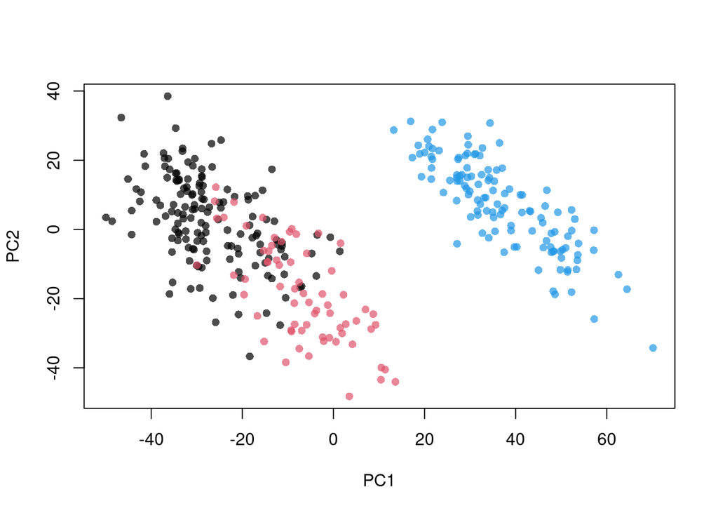

```r
library(palmerpenguins)
library(tidyverse)
library(kernlab)
pX <- (penguins
    |> select(where(is.numeric))
    |> select(-year)
    |> as.matrix()
    |> scale()
    |> na.omit()
)
## want species to match with NA-adjusted matrix!
ss <- penguins |> drop_na(where(is.numeric)) |> pull(species)
cc <- adjustcolor(palette()[c(1,2,4)], alpha.f = 0.7)
pfun <- function(k) {
    plot(rotated(k),col= cc[ss], pch = 16,
         xlab = "PC1", ylab = "PC2")
}
k0 <- kpca(pX, kernel = "vanilladot", kpar = list())
pfun(k0)
```

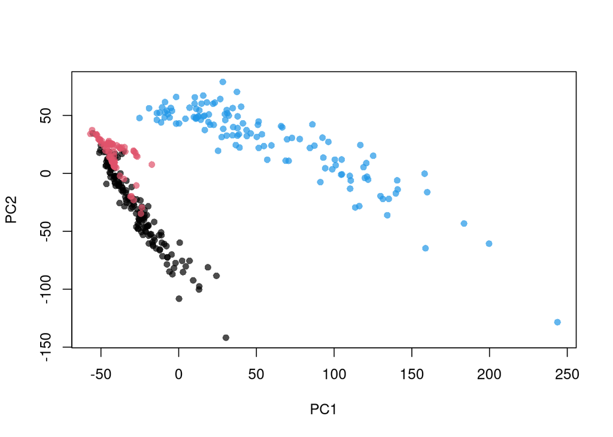

```r
k1 <- kpca(pX, kernel = "polydot", kpar = list(degree = 2))
pfun(k1)
```

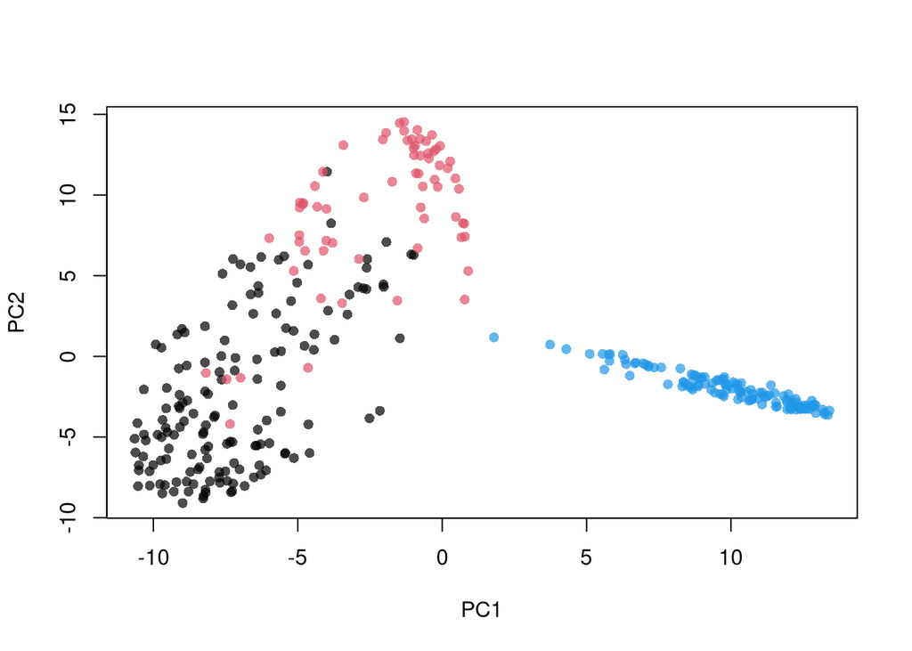

```r
k2 <- kpca(pX, kernel = "rbfdot", kpar = list(sigma = 0.5))
pfun(k2)
```

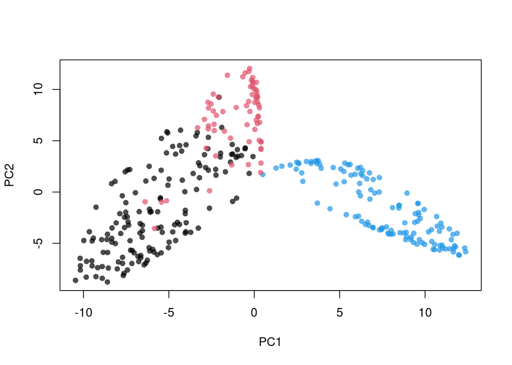

```r
k3 <- kpca(pX, kernel = "rbfdot", kpar = list(sigma = 1))
pfun(k3)
```

## expanded PCA by hand

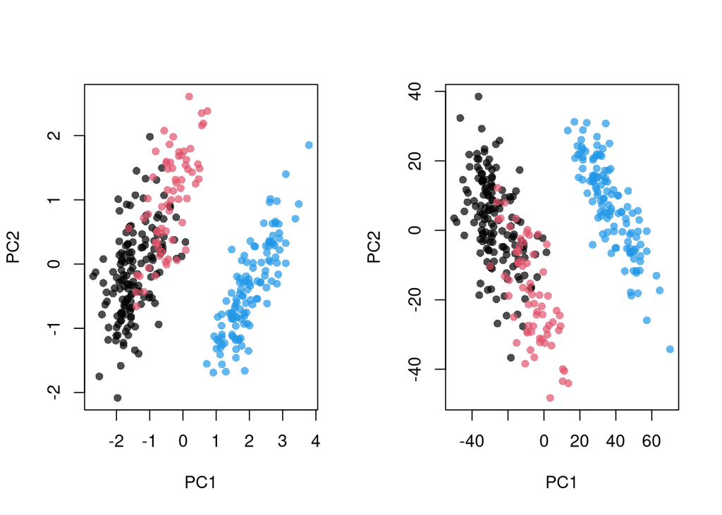

```r
pfun2 <- function(p) {
    plot(p$scores[,1], p$scores[,2], col= cc[ss], pch = 16,
         xlab = "PC1", ylab = "PC2")
}
p0 <- princomp( ~ ., data = as.data.frame(pX))
polyform <- (sprintf("poly(%s, degree = 2)", paste(colnames(pX), collapse = ","))
    |> reformulate()
)
X <- model.matrix(polyform, data = as.data.frame(pX))
p1 <- princomp( polyform, data = as.data.frame(pX))
par(mfrow = c(1, 2)); pfun2(p0); pfun(k0)
```

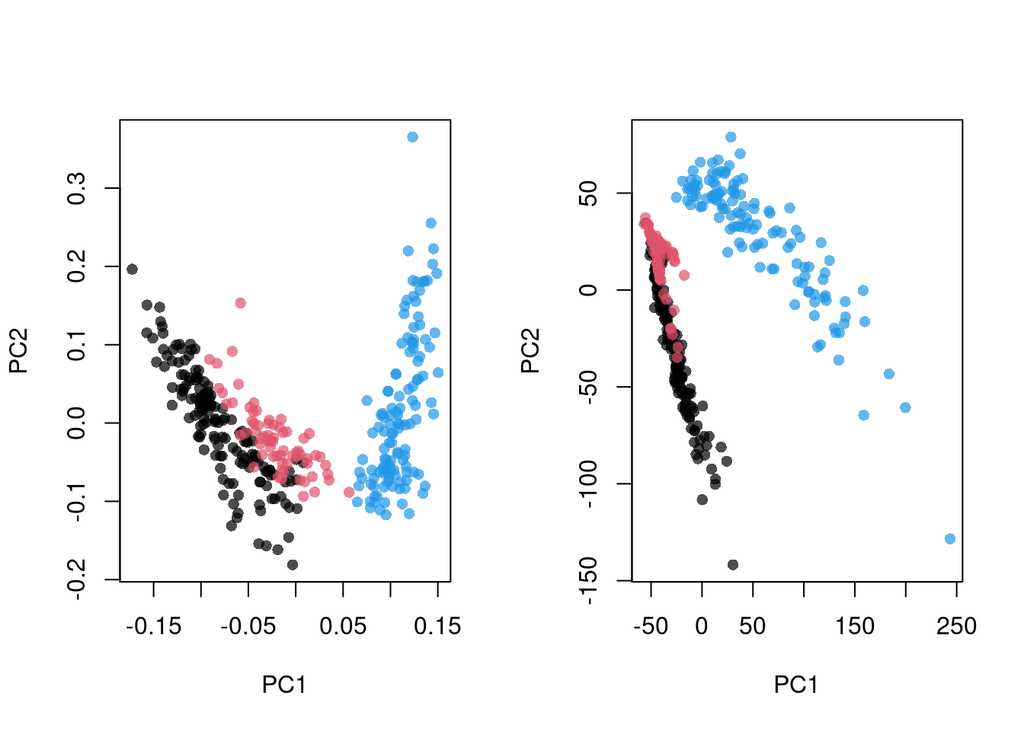

```r
par(mfrow = c(1, 2)); pfun2(p1); pfun(k1)
```

[how should one choose a kernel?](https://stats.stackexchange.com/questions/131142/how-to-choose-a-kernel-for-kernel-pca) - if kPCA is a step in a pipeline, make the kernel type and parameters (e.g. scale for RBF) part of the tuning process

## Gaussian processes

- Rasmussen and Williams (2005); Krasser (2018); Krasser (2020)
- motivated by Bayesian context, or from classical **geostatistics** (kriging)
- interpolation vs. approximation
- “Under the assumption of Gaussian observation noise the computations needed to make predictions are tractable and are dominated by the inversion of a n × n matrix.”
- zero-mean Gaussian prior: $\mathbf w\sim {\cal N}(\boldsymbol 0, \Sigma_p)$
- $\Sigma_p$? **positive definite** function of distance
  - $\mathbf x^\top \Sigma \mathbf x> 0$ for all $\mathbf x\neq 0$
  - all eigenvalues of $\Sigma$ are positive
- only certain **autocovariance functions** $f(r)$ satisfy this condition for all possible $\mathbf x$: RBF, Matérn, …

Krasser, Martin. 2018. “Gaussian Processes.” http://krasserm.github.io/2018/03/19/gaussian-processes/.

———. 2020. “Sparse Gaussian Processes.” http://krasserm.github.io/2020/12/12/gaussian-processes-sparse/.

## GP prior

$$\left(
\begin{array}{c}
f \\ f_*
\end{array}
\right)
\sim
{\cal N}
\left(
\boldsymbol 0,
\left(
\begin{array}{cc}
\mathbf K& \mathbf K_* \\
\mathbf K_*^\top & \mathbf K_{**} \\
\end{array}
\right)
\right)$$

## conditional posterior distribution

$$\begin{split}
\mu_* & = \mathbf K_*^\top \mathbf K^{-1} f \\
\Sigma_* & = \mathbf K_{**} - \mathbf K_*^\top \mathbf K^{-1} \mathbf K
\end{split}$$

**kriging equations**

## observation variance/measurement error

- **nugget variance**
- allow smoothing rather than interpolation
- cf SVM without complete separation

## hyperparameters

- variance of Gaussian process
- observation variance ‘scale’ (residual variance)
  - *could* estimate by cross-validation etc.
  - but have MLE, Bayesian estimates immediately available …
  - level of uncertainty between interpolating points
  - can estimate directly from MVN MLE as $y^\top C y$
- length scale

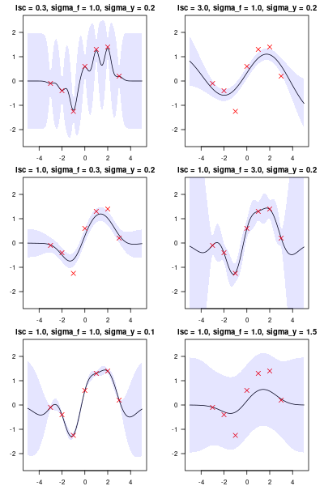

## estimating hyperparameters

- residual variance is easy
- length scale and $\sigma^2_f$ **can** be estimated by MLE
  - derivatives are available, so gradient descent/quasi-Newton methods are OK
  - … but … “Our examples show that this maximization may be fraught with difficulties.” Warnes and Ripley (1987)

Warnes, J. J., and B. D. Ripley. 1987. “Problems with Likelihood Estimation of Covariance Functions of Spatial Gaussian Processes.” *Biometrika* 74 (3): 640–42. http://www.jstor.org/stable/2336705.

## kernel shape

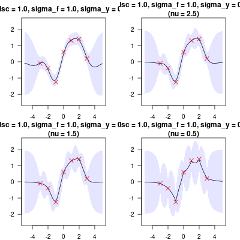

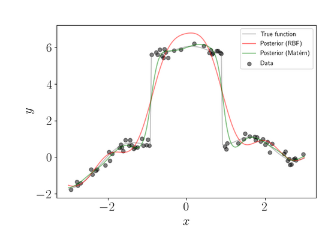

Jones (2021)

Jones, Andy. 2021. “The Matérn Class of Covariance Functions.” *Andy Jones*. https://andrewcharlesjones.github.io/journal/matern-kernels.html.

- (also: power-family $\exp(-|d|^p)$, etc. etc. etc.)

## stationarity and isotropy

- **isotropy**: exchangeability of parameters/directions
  - easy fix: **separable** priors (different variance for each direction)
  - i.e., different length scales in each direction
  - could?? model prior correlation as well)
- **stationarity**: kernel depends only on $||x_i-x_j||$
  - non-stationary: location-dependent, center at mean?
  - or model linear covariates + GP

Paciorek and Schervish (2003)

Paciorek, Christopher, and Mark Schervish. 2003. “Nonstationary Covariance Functions for Gaussian Process Regression.” In *Advances in Neural Information Processing Systems*. Vol. 16. MIT Press. https://proceedings.neurips.cc/paper/2003/hash/326a8c055c0d04f5b06544665d8bb3ea-Abstract.html.

## GPs and splines

- Rasmussen and Williams (2005)
- `?mgcv::smooth.construct.gp.smooth.spec`
- Kammann and Wand (2003)
  - choose Matérn with $\nu = 3/2$
  - choose scale == max distance between sample points
  - only need to estimate $\sigma^2_f$
  - fit linear mixed model

Rasmussen, Carl Edward, and Christopher K. I. Williams. 2005. *Gaussian Processes for Machine Learning*. Cambridge, Mass: The MIT Press.

Kammann, E. E., and M. P. Wand. 2003. “Geoadditive Models.” *Journal of the Royal Statistical Society: Series C (Applied Statistics)* 52 (1): 1–18. https://doi.org/10.1111/1467-9876.00385.

$$\begin{split}
\mathbf Z& = K(||x_i-\kappa_k||/\rho) \\
\boldsymbol \Omega& = K(||\kappa_k -\kappa_k'||/\rho) \\
\mathbf y& = \mathbf X\boldsymbol \beta+ \mathbf Zu + \epsilon
\end{split}$$

minimize $||\mathbf y- \mathbf X\beta + \mathbf Zu||_2^2 + ||\Omega^{-1} u||_2^2$

## combining kernels

- can multiply kernels, corresponds to *Kronecker product* of kernel matrices
- e.g. pick RBF for time, Matérn for space
- Bourotte, Allard, and Porcu (2016)

Bourotte, Marc, Denis Allard, and Emilio Porcu. 2016. “A Flexible Class of Non-Separable Cross-Covariance Functions for Multivariate Space–Time Data.” *Spatial Statistics*, Spatial Statistics Avignon: Emerging Patterns, 18 (November): 125–46. https://doi.org/10.1016/j.spasta.2016.02.004.

> Often, separability is an overly simplified assumption for weather and climate data. Space–time separability is equivalent to conditional independence between $Z(s,t)$ and $Z(s', t')$ given $Z(s, t')$ (or $Z(s', t)$)

## Bayesian model tuning/hyperparameter tuning

- `tune_bayes`
- https://www.tidymodels.org/learn/work/bayes-opt/

## scalable GPs

Banerjee (2017)

Banerjee, Sudipto. 2017. “High-Dimensional Bayesian Geostatistics.” *Bayesian Analysis* 12 (2): 583–614. https://doi.org/10.1214/17-BA1056R.

## low-rank representations

- pick a smaller number of knots
- work with/invert the Gram matrix $K$ over the knots (only)
- multiply by weights based on knot-to-point kernel values
- results may oversmooth/underestimate variability in the function/overestimate residual variance (nugget)
- complexity of ${\cal O}(n r^2)$, but $r$ has to be big then …
- (i.e. may break down between $n = 10^4$ and $n = 10^6$)

## covariance tapering

- multiply $K$ by a compactly supported tapering function (also pos def)
- sets covariance to zero at long distances
- need efficient sparse linear algebra …

## nearest-neighbour Gaussian processes

- work with the **precision** matrix instead $K^{-1}$
- sparse Gaussian graphical models
- **conditionally independent** points $x_i$, $x_j$ have $K^{-1}_{ij} = 0$

## packages

`plgp`, `spectralGP`, `GauPro`, `tfprobability`, `mlegp`, …

sparse GPs: `psgp`